# Classification

# Default example

- You should google ROC curve and confusion matrix
- ROC can be used to determined the best classification boundary
- ROC can be used to compare models. Large (AUC) is good.

# Linear Discriminant Analysis (LDA)

- $p=1$
- In classification, we try to find
  $$p_k(x)\equiv P(Y=k|X=x)=\frac{\pi_k f_k(x)}{\sum_{l=1}^{K}\pi_l f_l(x)}$$
- Bayes classifier: $\hat{Y}=k$ if
  $$P(Y=k|X=x)>P(Y=j|X=x)$$
  for all $j\ne k$
- $\hat{Y}=k$ if
  $$\pi_k f_k(x)>\pi_j f_j(x)$$

# Linear Discriminant Analysis (LDA)

- $p=1$
- Assume that $f_k(x)$ is normal with mean $\mu_k$ and standard deviation $\sigma$.
- Then
  $$p_k(x)=\frac{\pi_k \frac{1}{\sqrt{2\pi} \sigma}\exp (-(x-\mu_k)^2/2\sigma^2)}{\sum_{l=1}^{K}\pi_l \frac{1}{\sqrt{2\pi} \sigma}\exp (-(x-\mu_l)^2/2\sigma^2)}$$
- The discriminat function is
  $$\delta_k(x)=x\frac{\mu_k}{\sigma^2}-\frac{\mu_k^2}{2\sigma^2}+\log{\pi_k}$$

# Quadratic Discriminant Analysis (QDA)

- $p=1$
- Assume that $f_k(x)$ is normal with mean $\mu_k$ and standard deviation $\sigma$.
- Then
  $$p_k(x)=\frac{\pi_k \frac{1}{\sqrt{2\pi} \sigma_k}\exp (-(x-\mu_k)^2/2\sigma_k^2)}{\sum_{l=1}^{K}\pi_l \frac{1}{\sqrt{2\pi} \sigma}\exp (-(x-\mu_l)^2/2\sigma_k^2)}$$
- The discriminat function is
  $$\delta_k(x)=-\frac{x^2}{2\sigma_k^2}+x\frac{\mu_k}{\sigma_k^2}-\frac{\mu_k^2}{2\sigma_k^2}+\log{\pi_k}$$

# Linear Discriminant Analysis (LDA)

- One need to estimate $\pi_k$, $\mu_k$ and $\sigma^2$
- $$\hat{\mu}_k=\frac{1}{n_k}\sum_{i: y_i=k} x_i$$
- $$\hat{\sigma}^2=\frac{1}{n-K}\sum_{k=1}^K \sum_{i: y_i=k} (x_i-\hat{\mu}_k)^2$$
- $$\hat{\pi}_k=n_k/n$$

# Relationship between LDA and Logistic regression

- If $f_k(x)$ is normal, then

$$\log \frac{p_1(x)}{p_0(x)}=c_0+c_1 x$$

# Linear Discriminant Analysis (LDA)

- $p>1$
- given $Y=k$, $X$ is normal with mean vector $\mu_k$ and covariance matrix $\Sigma$.
- $$f(x|k)=\frac{1}{(2\pi)^{p/2} }\exp(-\frac{1}{2}(x-\mu_k)^\top \Sigma^{-1}(x-\mu_k))$$
- $$\delta_k(x)=x^T \Sigma^{-1}\mu_k-\frac{1}{2}\mu_k^T \Sigma^{-1}\mu_k$$

# Quadratic Discriminant Analysis (QDA)

- $p>1$
- $K=k, p>1$, given $Y=k$, $X$ is normal with mean vector $\mu_k$ and covariance matrix $\Sigma_k$.
- $$\delta_k(x)=-\frac{1}{2}x^T \Sigma_k^{-1}x + x^T \Sigma_k^{-1}\mu_k-\frac{1}{2}\mu_k^T \Sigma_k^{-1}\mu_k-\frac{1}{2} \log |\Sigma_k|+ \log \pi_k$$

# LDA and QDA

- variance-bias trade off
  - LDA: with $p$ predictors and $K$ classes, the covariance matrix has $p(p+1)/2$ parameters
  - QDA: with $p$ predictors and $K$ classes, the covariance matrix has $K p(p+1)/2$ parameters
  - LDA discriminant is a linear function of the predictors, QDA discriminant is a quadratic function of the predictors.

# Naive Bayesian

- assume that $x_i$, $i=1, \cdots, p$ are independent

# R implementation of LDA and QDA

```r
library(ISLR)
library(MASS)
Default<-na.omit(Default)

Default.lda <- lda(default ~ balance+ income, data = Default)
Default.lda
```

```
## Call:
## lda(default ~ balance + income, data = Default)
##
## Prior probabilities of groups:
##     No    Yes
## 0.9667 0.0333
##
## Group means:
##       balance   income
## No   803.9438 33566.17
## Yes 1747.8217 32089.15
##
## Coefficients of linear discriminants:
##                  LD1
## balance 2.230835e-03
## income  7.793355e-06
```

```r
pre.Default.lda<- predict(Default.lda)
names(pre.Default.lda)
```

```
## [1] "class"     "posterior" "x"
```

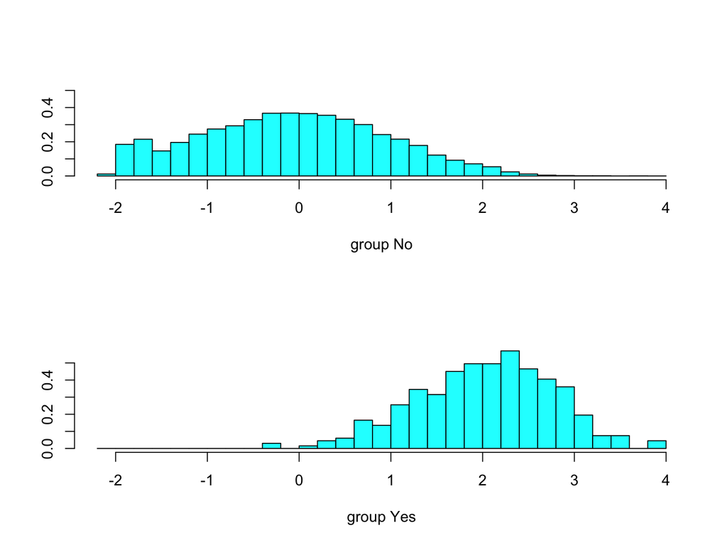

```r
ldahist(pre.Default.lda$x, g = Default$default)
```

```r
table(Default$default, pre.Default.lda$class)
```

```
##
##         No  Yes
##   No  9647   20
##   Yes  256   77
```

```r
my.lda.pre<-rep("No", length(Default$default))
my.lda.pre[pre.Default.lda$posterior[, "Yes"] >0.2]<-"Yes"

table(Default$default, my.lda.pre)
```

```
##      my.lda.pre
##         No  Yes
##   No  9427  240
##   Yes  144  189
```

# R implementation of LDA and QDA

- Use training and test set

```r
n<-length(Default$default)
train_n<-sample(1:n, floor(n/2))
train_D<-Default[train_n,]
test_D<-Default[-train_n,]

lda.train <- lda(default ~ balance+ income, data = train_D)

#test error
pre.D.lda<- predict(lda.train, test_D)
t1<-table(test_D$default, pre.D.lda$class)
prop.table(t1,1)
```

```
##
##               No        Yes
##   No  0.99731405 0.00268595
##   Yes 0.74375000 0.25625000
```

```r
#train error
pre.D.lda<- predict(lda.train, train_D)
t1<-table(train_D$default, pre.D.lda$class)
prop.table(t1,1)
```

```
##
##                No         Yes
##   No  0.998549824 0.001450176
##   Yes 0.774566474 0.225433526
```

# R implementation of LDA and QDA

- Use training and test set

```r
## qda

qda.train <- qda(default ~ balance+ income, data = train_D)

#qda test error
pre.D.qda<- predict(qda.train, test_D)
t1<-table(test_D$default, pre.D.qda$class)
prop.table(t1,1)
```

```
##
##                No         Yes
##   No  0.996694215 0.003305785
##   Yes 0.700000000 0.300000000
```

```r
#train error
pre.D.qda<- predict(qda.train, train_D)
t1<-table(train_D$default, pre.D.qda$class)
prop.table(t1,1)
```

```
##
##                No         Yes
##   No  0.997099648 0.002900352
##   Yes 0.739884393 0.260115607
```

```r
##
```

- comparison results do depend on how you split data

# LDA for iris data

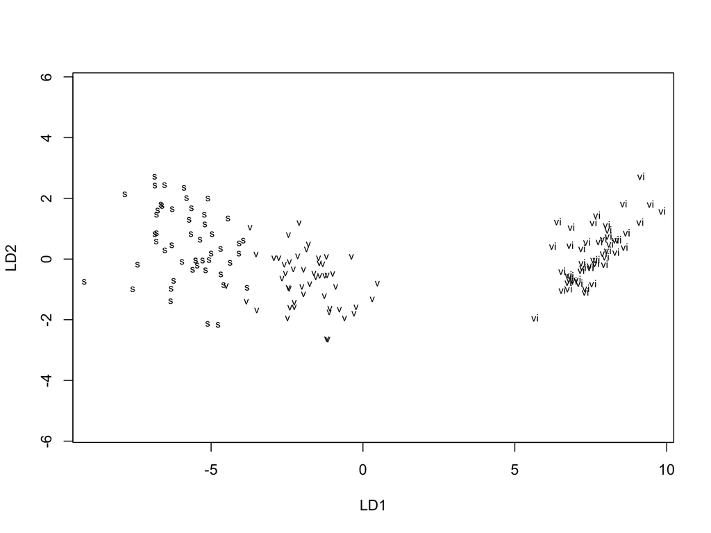

```r
library(MASS)
levels(iris$Species)<- c("vi","v","s")
LDA <- lda(Species ~ ., data = iris)
 X <- data.frame(predict(LDA)$x)
plot(LDA)
```

```r
LDA.p<-predict(LDA)
table(iris$Species, "LDA Prediction"=LDA.p$class)
```

```
##     LDA Prediction
##      vi  v  s
##   vi 50  0  0
##   v   0 48  2
##   s   0  1 49
```

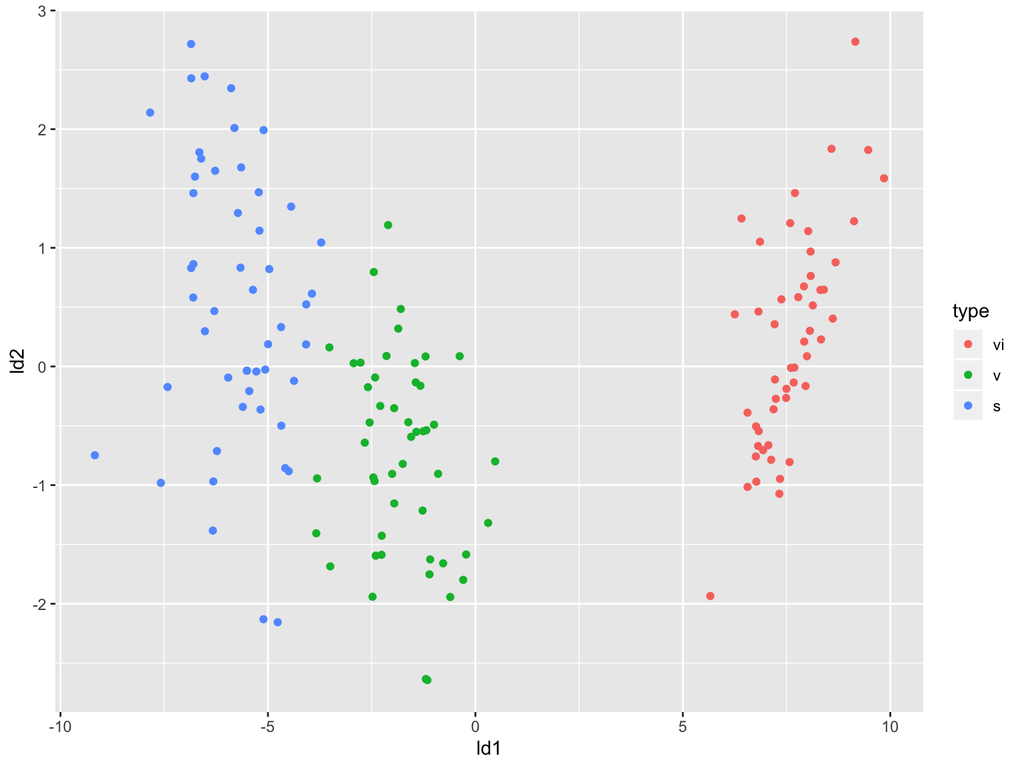

```r
library(ggplot2)
new.d<-data.frame(ld1=LDA.p$x[,1], ld2=LDA.p$x[,2], type=LDA.p$class)
ggplot(new.d, aes(x=ld1, y=ld2, colour=type))+geom_point()
```

# KNN classification

```r
library(class)
library(ISLR)

Default<- Default[,c("default", "balance", "income")]
# scale the data
Default.scale<- scale(Default[,-c(1)])

n<-length(Default$default)
train_n<-sample(1:n, floor(n/2))
train_D<-Default.scale[train_n,]
test_D<-Default.scale[-train_n,]
train_y<-Default[train_n,"default"]
test_y<-Default[-train_n,"default"]

knn.pre<-knn(train_D, test_D, train_y, k=5)
table(test_y, knn.pre)
```

```
##       knn.pre
## test_y   No  Yes
##    No  4808   38
##    Yes   98   56
```

# KNN classification

- It usually better to scale the predictor first
- use test error to select k

# Comparison of methods

- variance-bias trade off
  - LDA: with $p$ predictors and $K$ classes, the covariance matrix has $p(p+1)/2$ parameters
  - QDA: with $p$ predictors and $K$ classes, the covariance matrix has $K p(p+1)/2$ parameters
  - LDA discriminant is a linear function of the predictors, QDA discriminant is a quadratic function of the predictors.
- Assumptions:
  - LDA and QDA: normal predictors
  - KNN nonparametric
- Use testing error to compare
- Section 4.5 of the textbook